# Erin Liu HW5

```r
city_hotel_data %>%
  group_by(city_lead_time_category=cut(lead_time, breaks= seq(0, 300, by = 30), right=F) ) %>%
  summarise(lead_time_frequency= n()) %>%
  arrange(as.numeric(city_lead_time_category))
```

```
# A tibble: 10 × 2
   city_lead_time_category lead_time_frequency
   <fct>                                 <int>
 1 [0,30)                                19296
 2 [30,60)                               11949
 3 [60,90)                                8949
 4 [90,120)                               7435
 5 [120,150)                              5520
 6 [150,180)                              5205
 7 [180,210)                              3654
 8 [210,240)                              2518
 9 [240,270)                              2128
10 [270,300)                              2525
```

This is the visualization between the city_lead_time_category and the count in each category. It shows the distribution of lead_time data in different ranges. We can tell from this graph that most of the lead_time happen in the range of 0-60 and the number of count decreases as lead_time goes larger. However, there are a quite number of extreme numbers around 270-300 which could be affecting the overall conclusion for further analysis.

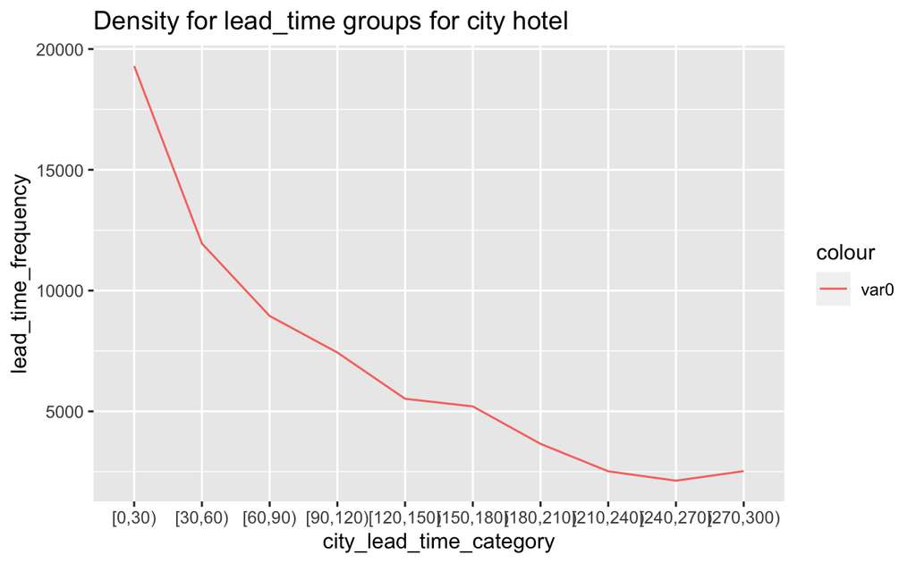

```r
city_hotel_data %>%
  group_by(city_lead_time_category=cut(lead_time, breaks= seq(0, 300, by = 30), right=F) ) %>%
  summarise(lead_time_frequency= n()) %>%
  arrange(as.numeric(city_lead_time_category)) %>%
  ggplot(aes(city_lead_time_category, group = 1)) +
  geom_line(aes(y = lead_time_frequency, colour = "var0")) +
  labs(title = "Density for lead_time groups for city hotel")
```

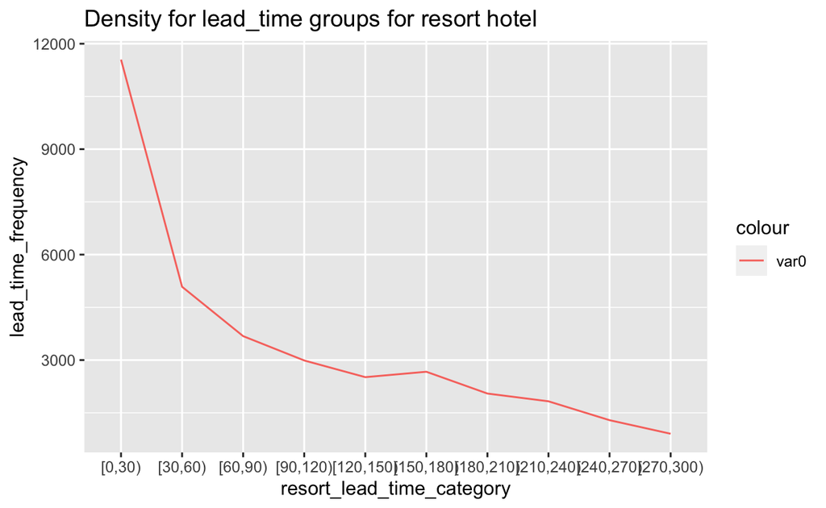

```r
resort_hotel_data %>%
  group_by(resort_lead_time_category=cut(lead_time, breaks= seq(0, 300, by = 30), right=F) ) %>%
  summarise(lead_time_frequency= n()) %>%
 arrange(as.numeric(resort_lead_time_category)) %>%
  ggplot(aes(resort_lead_time_category, group = 1)) +
 geom_line(aes(y = lead_time_frequency, colour = "var0")) +
  labs(title = "Density for lead_time groups for resort hotel")
```

This is the visualization of ADR’s distribution, and it helps us to understand the data more besides the conclusion from mean/median and we can see the peak of frequency happens in around 50.

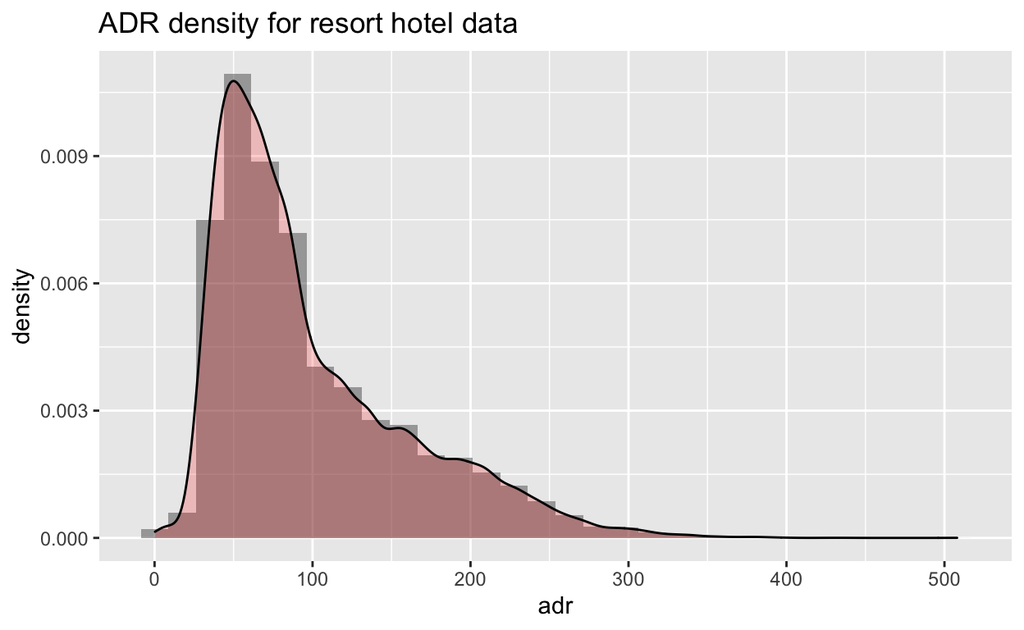

```r
ggplot(resort_hotel_data, aes(adr)) +
  geom_histogram(aes(y = ..density..), alpha = 0.5) +
  labs(title = "ADR density for resort hotel data") +
  geom_density(alpha = 0.2, fill="red")
```

This is the visualization for ADR and different room types. We can see that room type A has the largest number and almost every type has an average of daily rate around 0-200 except for room type F which seems to have a higher average around 200-300. This could be better scaled to show more information for the less popular types.

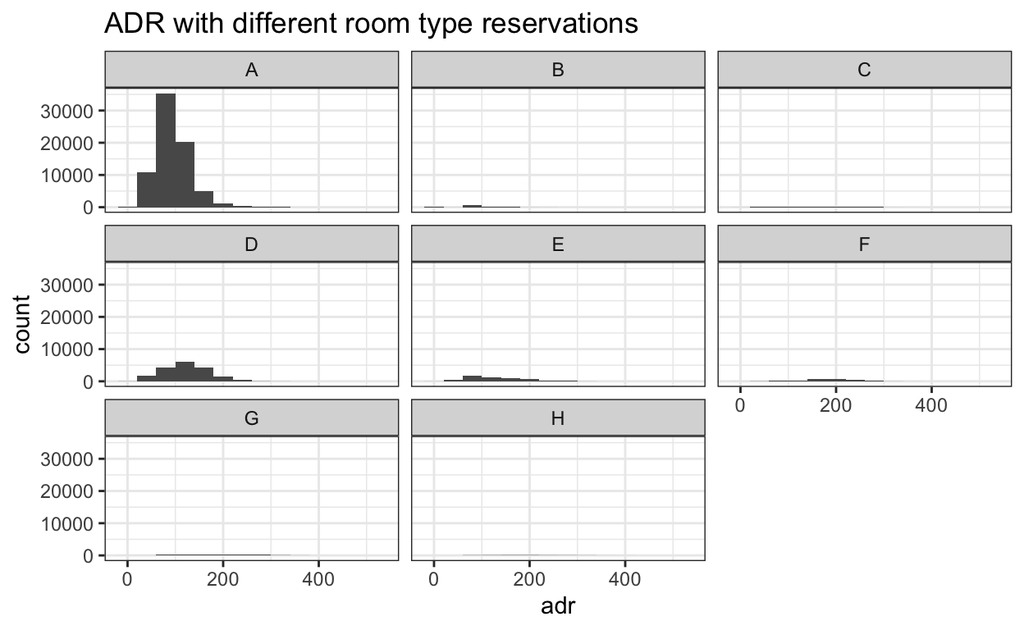

```r
all_data <- filter(HW3_data, adr > 0 & lead_time>0 & lead_time<300 & adr <2000 )
ggplot(all_data, aes(adr)) +
  geom_histogram(binwidth = 40) +
  labs(title = "ADR with different room type reservations") +
  theme_bw() +
  facet_wrap(vars(reserved_room_type))
```

This is the visualization between different customer types and ADR. We can see that type Transient is the most popular type and almost every type has a median of ADR around 100. This could be better scaled to show more information for the less popular types.

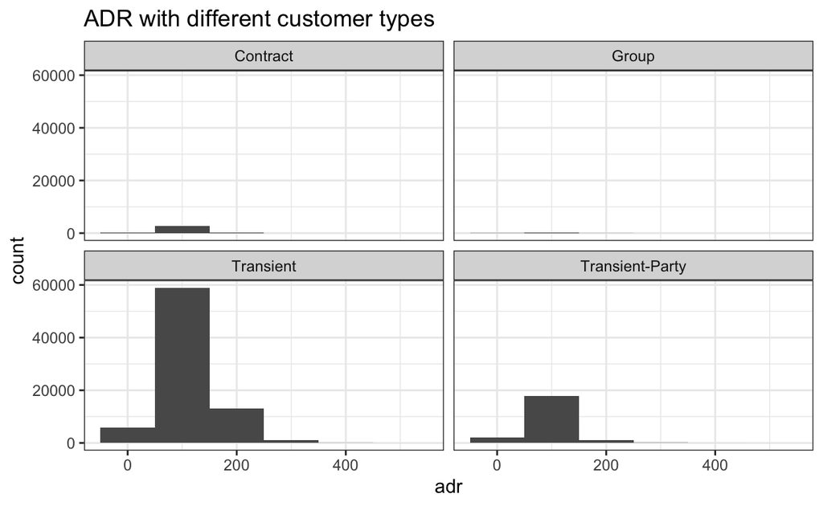

```r
all_data <- filter(HW3_data, adr > 0 & lead_time>0 & lead_time<300 & adr <2000 )
ggplot(all_data, aes(adr)) +
  geom_histogram(binwidth = 100) +
  labs(title = "ADR with different customer types") +
  theme_bw() +
  facet_wrap(vars(customer_type))
```

This is the visualization between adr and lead_time, which is the essential question of this project to study the relation between adr and lead_time: how do they affect each other and what’s their distributions, etc. We can see the data points gather around the bottom left corner and centralized around x=60. It also shows that people can usually get a good price with lead_time less than 20 days so planning ahead of time isn’t that necessary to get a good price.

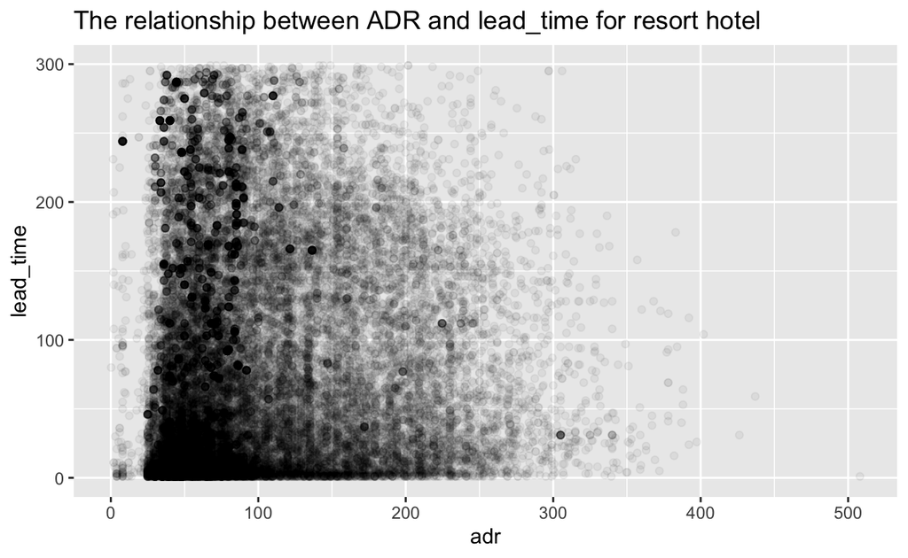

```r
ggplot(resort_hotel_data, aes(adr, lead_time)) + geom_point(alpha=0.05) +
labs(title = "The relationship between ADR and lead_time for resort hotel")
```

For the next HW I will compare the trend in different hotel types(resort vs city) which has not been implemented so far. And some visualizations in this HW need to be scaled properly to show more information. I also want them to show numeric data point on the graph. I used to think that lead_time will influence the ADR largely under the impression that my parents always booked the hotel way ahead of time. But it turns out to be not the case and the current conclusion is that lead_time does not have a clear relationship with ADR. Room types and customer types will definitely influence the ADR and I will further study the relationship in it. I think for naive reader to fully understand my graphs they will need to look at the x and y value in the graph and the title and my explanation.